# Лабораторная работа №6

Задача об эпидемии

Танрибергенов Эльдар

Российский университет дружбы народов, Москва, Россия

2023 г.

## Цели и задачи

Рассмотреть простейшую модель эпидемии на примере задачи.

Задача:

На одном острове вспыхнула эпидемия. Известно, что из всех проживающих на острове (*N* = 6666) в момент начала эпидемии (*t* = 0) число заболевших людей (являющихся распространителями инфекции) *I*(0) = 83, а число здоровых людей с иммунитетом к болезни *R*(0) = 6. Таким образом, число людей восприимчивых к болезни, но пока здоровых, в начальный момент времени *S*(0) = *N* − *I*(0) − *R*(0).

Построить графики изменения числа особей в каждой из трех групп. Рассмотреть, как будет протекать эпидемия в случае:

1. если *I*(0) ≤ *I**
2. если *I*(0) > *I**

## Материалы и методы

- Julia
- OpenModelica

# Выполнение работы

## Изучение теории

Если *I*(0) ≤ *I**, то

$$\begin{cases}
\frac{dS}{dt} = 0
\\
\frac{dI}{dt} = - \beta I
\\
\frac{dR}{dt} = \beta I
\end{cases}$$

Если *I*(0) > *I**

$$\begin{cases}
\frac{dS}{dt} = -\alpha S
\\
\frac{dI}{dt} = \alpha S- \beta I
\\
\frac{dR}{dt} = \beta I
\end{cases}$$

## Написание кода для первого случая

Фрагмент кода на Julia

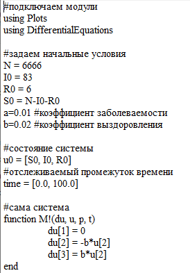

Код на OpenModelica

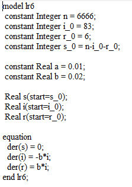

## Результаты для первого случая

Из Julia

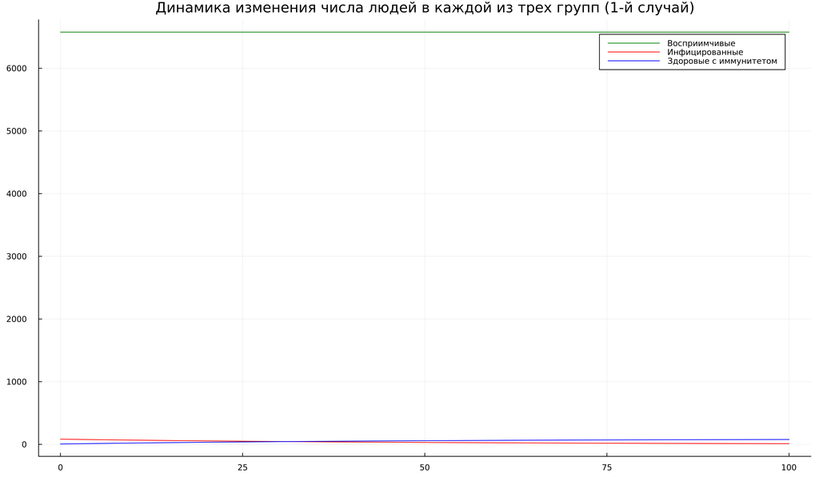

Из OpenModelica

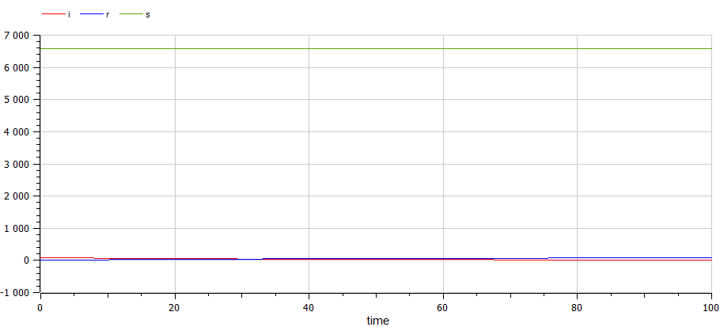

## Результаты, для первого случая

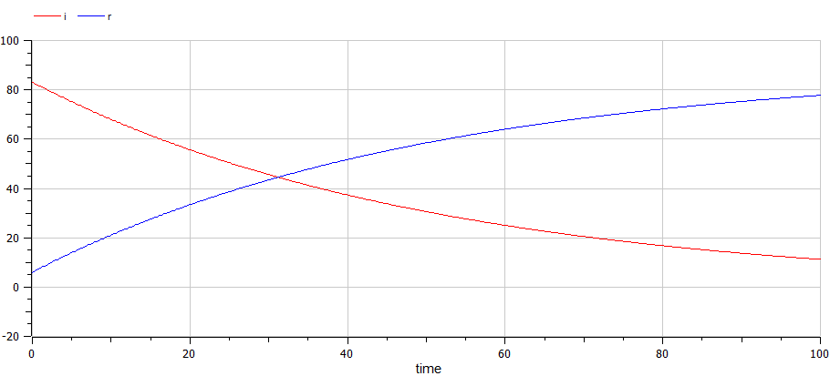

## Написание кода для второго случая

Фрагмент кода на Julia

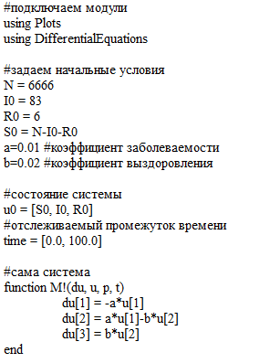

Код на OpenModelica

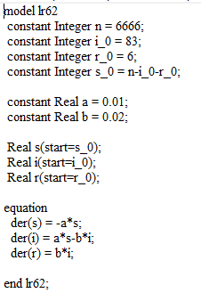

## Результаты для второго случая

Из Julia

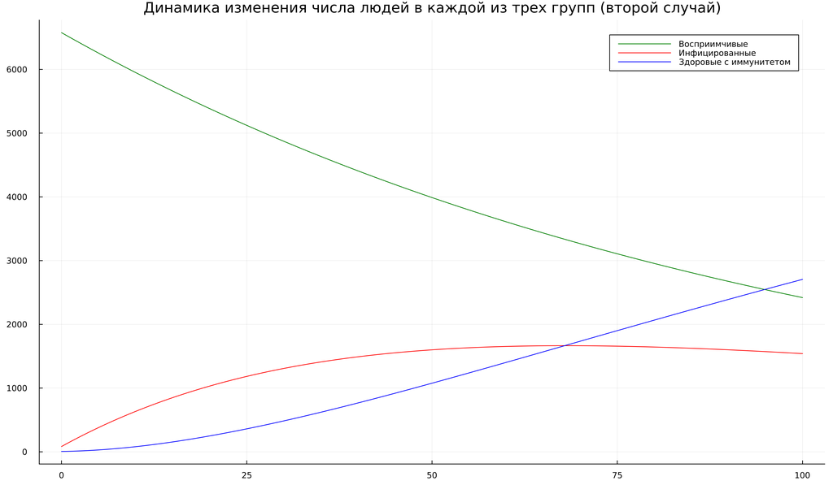

Из OpenModelica

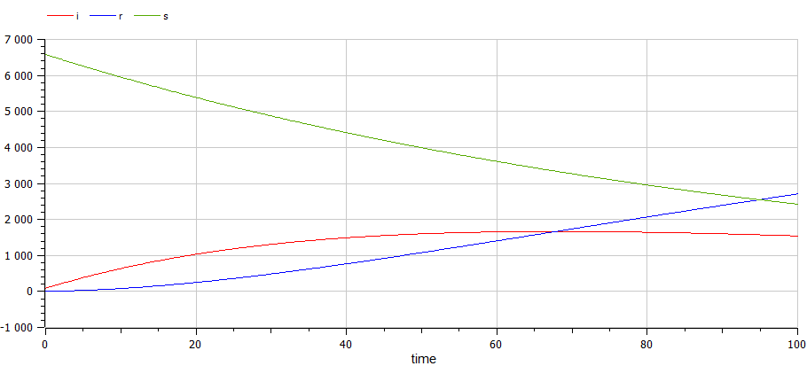

# Результаты

## Результат

Рассмотрена простейшая модель эпидемии на примере задачи. Построены графики изменения числа особей в каждой из трех групп. Рассмотрено, как будет протекать эпидемия в случае:

1. если *I*(0) ≤ *I**
2. если *I*(0) > *I**

# Вывод

## Вывод

Я рассмотрел простейшую модель эпидемии. Выполнил задание согласно варианту: построил графики изменения числа особей в каждой из трех групп для двух случаев.